# Who Checkmated?

Predicting the winner of a chess game

Maeva Assi

2025-05-06

# Introduction:

In chess, the player with the light-colored pieces is referred to as “White” and the player with the dark-colored pieces is referred to as “Black”. White moves first, after which players alternate turns.  
Each player starts with sixteen pieces: one King, one Queen, two Rooks, two Knights, two Bishops, and eight Pawns. The main point of chess is to **checkmate the opponent’s King**.

**Checkmate** (often shortened to mate) means **attacking the King so that it cannot escape capture**, thus ending the game.  
The King is never actually captured – a player loses as soon as their King is checkmated.  
A game also ends if a player resigns or forfeits, or if time runs out for one of the players but today’s article will focus on games ending in **checkmates** only.

[figure not shown]

The [Chess Game Dataset](https://github.com/rfordatascience/tidytuesday/blob/main/data/2024/2024-10-01/readme.md) is a set of just over 20,000 games collected from a selection of users from the free open source chess server **Lichess.org** via [Kaggle by Mitchell J.](https://www.kaggle.com/datasets/datasnaek/chess/data).  
The set contains the 16 following variables for each game:

- `game_id`: Game ID;
- `rated`: Rated (T/F), which is whether the game was a rated game (which will affect your rating in the platform), or a “casual” game.
- `start_time`: Start time;
- `end_time`: End time;
- `turns`: Number of turns;
- `victory_status`: Game status (mate, resign, draw, out of time);
- `winner`: Winner (white, black, draw);
- `time_increment`: Time increment;
- `white_id`: White player id;
- `white_rating`: White player rating;
- `black_id`: Black player id;
- `black_rating`: Black player rating;
- `moves`: All Moves in Standard Chess Notation;
- `opening_eco`: Opening Eco (Standardised Code for any given opening, list [here](https://www.365chess.com/eco.php))
- `opening_name`: Opening Name; and
- `opening_ply`: Number of moves in the opening phase.

Because chess is an abstract strategy game which involves no hidden information and no elements of chance, I’m curious as to what allows a player to win as black or white. **Question**: Is there a relationship between player level and victory by checkmate? Can we predict if a game resulted in a black or white winner depending on the player level?

# I. Data Import and Wrangling

I imported the data directly from GitHub.

```r
# Importing the data
chess <- readr::read_csv('https://raw.githubusercontent.com/rfordatascience/tidytuesday/main/data/2024/2024-10-01/chess.csv')

# Looking at the data
glimpse(chess)
```

```
## Rows: 20,058
## Columns: 16
## $ game_id        <chr> "TZJHLljE", "l1NXvwaE", "mIICvQHh", "kWKvrqYL", "9tXo1A…
## $ rated          <lgl> FALSE, TRUE, TRUE, TRUE, TRUE, FALSE, TRUE, FALSE, TRUE…
## $ start_time     <dbl> 1.50421e+12, 1.50413e+12, 1.50413e+12, 1.50411e+12, 1.5…
## $ end_time       <dbl> 1.50421e+12, 1.50413e+12, 1.50413e+12, 1.50411e+12, 1.5…
## $ turns          <dbl> 13, 16, 61, 61, 95, 5, 33, 9, 66, 119, 39, 38, 60, 31, …
## $ victory_status <chr> "outoftime", "resign", "mate", "mate", "mate", "draw", …
## $ winner         <chr> "white", "black", "white", "white", "white", "draw", "w…
## $ time_increment <chr> "15+2", "5+10", "5+10", "20+0", "30+3", "10+0", "10+0",…
## $ white_id       <chr> "bourgris", "a-00", "ischia", "daniamurashov", "nik2211…
## $ white_rating   <dbl> 1500, 1322, 1496, 1439, 1523, 1250, 1520, 1413, 1439, 1…
## $ black_id       <chr> "a-00", "skinnerua", "a-00", "adivanov2009", "adivanov2…
## $ black_rating   <dbl> 1191, 1261, 1500, 1454, 1469, 1002, 1423, 2108, 1392, 1…
## $ moves          <chr> "d4 d5 c4 c6 cxd5 e6 dxe6 fxe6 Nf3 Bb4+ Nc3 Ba5 Bf4", "…
## $ opening_eco    <chr> "D10", "B00", "C20", "D02", "C41", "B27", "D00", "B00",…
## $ opening_name   <chr> "Slav Defense: Exchange Variation", "Nimzowitsch Defens…
## $ opening_ply    <dbl> 5, 4, 3, 3, 5, 4, 10, 5, 6, 4, 1, 9, 3, 2, 8, 7, 8, 8, …
```

As stated in the introduction, the dataset has 16 variables, however I only need the following for my project:

- `rated`: Rated (T/F), which is whether the game was a rated game (which will affect your rating in the platform), or a casual game.
- `victory_status`: Game status (mate, resign, draw, out of time);
- `winner`: Winner (white, black, draw);
- `white_rating`: White player rating; and
- `black_rating`: Black player rating.

I’m also only interested in games ending in **checkmates**, so I filtered for those and then select my variables of interest.  
I didn’t select the `victory_status` variable since it only takes “mate” as a value after filtering, making it redundant.  
As a reminder of the game rules, a checkmate cannot be a draw as it must result in a white or black winner, so I didn’t need to filter out “draw” from the `winner` variable after filtering the `victory_status`.

```r
chess_clean <- chess |>
  # Filtering for the relevant victory status
  filter(victory_status == "mate"
         ) |>
  # Selecting the variables of interest
  select(rated,
         winner,
         white_rating,
         black_rating
         )

glimpse(chess_clean)
```

```
## Rows: 6,325
## Columns: 4
## $ rated        <lgl> TRUE, TRUE, TRUE, TRUE, FALSE, FALSE, FALSE, TRUE, TRUE, …
## $ winner       <chr> "white", "white", "white", "white", "white", "white", "bl…
## $ white_rating <dbl> 1496, 1439, 1523, 1381, 1381, 1094, 1141, 1078, 1328, 107…
## $ black_rating <dbl> 1500, 1454, 1469, 1209, 1272, 1141, 1094, 1219, 1038, 114…
```

Filtering narrowed my data down to 6,325 games.

Next, since both the white and black player ratings are reported for each game, I created a variable that reports the rating of the winning player using a logical vector. This variable will be useful when doing data visualizations.

```r
# Creating a new variable that reports the rating of the winner
chess_clean <- chess_clean |>
  mutate(winner_rating = if_else(winner == "white", # condition: if White is the winner
                          white_rating, # if true, winner rating = white player rating
                          black_rating # if false, winner rating = black player rating
                          ),
         .after = winner
  ) |>
  mutate(loser_rating = if_else(winner != "white", # condition: if White is not the winner
                          white_rating, # if true, loser rating = white player rating
                          black_rating # if false, loser rating = black player rating
                          ),
         .after = winner_rating
  ) |>
  mutate(rating_difference = winner_rating - loser_rating,
         .after = winner_rating
  )  |>
  mutate(white_black_difference = white_rating - black_rating,
         .after = winner_rating
  )

glimpse(chess_clean)
```

```
## Rows: 6,325
## Columns: 8
## $ rated                  <lgl> TRUE, TRUE, TRUE, TRUE, FALSE, FALSE, FALSE, TR…
## $ winner                 <chr> "white", "white", "white", "white", "white", "w…
## $ winner_rating          <dbl> 1496, 1439, 1523, 1381, 1381, 1094, 1094, 1078,…
## $ white_black_difference <dbl> -4, -15, 54, 172, 109, -47, 47, -141, 290, -71,…
## $ rating_difference      <dbl> -4, -15, 54, 172, 109, -47, -47, -141, -290, 71…
## $ loser_rating           <dbl> 1500, 1454, 1469, 1209, 1272, 1141, 1141, 1219,…
## $ white_rating           <dbl> 1496, 1439, 1523, 1381, 1381, 1094, 1141, 1078,…
## $ black_rating           <dbl> 1500, 1454, 1469, 1209, 1272, 1141, 1094, 1219,…
```

Lastly, because the `rated` variable name and its values may be confusing at a first glance, I renamed the `rated` variable to `game_type`, converted it into a factor and renamed its levels. This will make my data visualizations easier to understand.  
I also converted the `winner` variable into a factor for modeling.

```r
chess_clean <- chess_clean |>
  # Renaming the variable
  rename("game_type" = rated) |>
  # Converting variables to factors
  mutate(game_type = factor(game_type),
         winner = factor(winner)
         ) |>
  # Renaming the game type levels
  mutate(game_type =  fct_recode(game_type,
                                 "Rated Game" = "TRUE",
                                 "Casual Game" = "FALSE"
                                 )
         ) |>
  # Releveling the winner levels
  mutate(winner =  fct_relevel(winner,
                                 "white",
                                 "black"
                               )
         )

glimpse(chess_clean)
```

```
## Rows: 6,325
## Columns: 8
## $ game_type              <fct> Rated Game, Rated Game, Rated Game, Rated Game,…
## $ winner                 <fct> white, white, white, white, white, white, black…
## $ winner_rating          <dbl> 1496, 1439, 1523, 1381, 1381, 1094, 1094, 1078,…
## $ white_black_difference <dbl> -4, -15, 54, 172, 109, -47, 47, -141, 290, -71,…
## $ rating_difference      <dbl> -4, -15, 54, 172, 109, -47, -47, -141, -290, 71…
## $ loser_rating           <dbl> 1500, 1454, 1469, 1209, 1272, 1141, 1141, 1219,…
## $ white_rating           <dbl> 1496, 1439, 1523, 1381, 1381, 1094, 1141, 1078,…
## $ black_rating           <dbl> 1500, 1454, 1469, 1209, 1272, 1141, 1094, 1219,…
```

## Exploring the Data

I also created a separate object for summary statistics of player_rating by winner.

```r
# Selecting the variables of interest
chess_avg <- chess_clean |>
  summarize(winner_n = n(),
            avg_diff = mean(winner_rating) - mean(loser_rating),
            avg_winner_rating = mean(winner_rating),
            median_winner_rating = median(winner_rating),
            max_winner_rating = max(winner_rating),
            max_winner_rating = max(winner_rating),
            min_winner_rating = min(winner_rating),
            .by = winner)
chess_avg
```

```
## # A tibble: 2 × 7
##   winner winner_n avg_diff avg_winner_rating median_winner_rat…¹ max_w…² min_w…³
##   <fct>     <int>    <dbl>             <dbl>               <dbl>   <dbl>   <dbl>
## 1 white      3344     109.             1576.               1544.    2621     784
## 2 black      2981     110.             1586.               1556     2621     796
## # … with abbreviated variable names ¹median_winner_rating, ²max_winner_rating,
## #   ³min_winner_rating
```

```r
# Selecting the variables of interest
chess_summary2 <- chess_clean |>
  summarize(winner_n = n(),
            diff_rating = white_rating - black_rating,
            .by = c(winner, winner_rating))
chess_summary2
```

```
## # A tibble: 6,325 × 4
##    winner winner_rating winner_n diff_rating
##    <fct>          <dbl>    <int>       <dbl>
##  1 white           1496        4          -4
##  2 white           1496        4           7
##  3 white           1496        4         180
##  4 white           1496        4         -50
##  5 white           1439        5         -15
##  6 white           1439        5         -15
##  7 white           1439        5         157
##  8 white           1439        5        -106
##  9 white           1439        5         -15
## 10 white           1523        9          54
## # … with 6,315 more rows
```

Player ratings range from 784 for white winners and 796 for black winners to 2,621 for both. The average player rating for black winners is 1,585.97, which is higher than the average player rating for white winners of 1,576.5 by 9.47.

6 of the top 10 players with the highest player rating won as white players.

```r
chess_clean |>
  slice_max(winner_rating, n = 10)
```

```
## # A tibble: 10 × 8
##    game_type   winner winner_rating white_blac…¹ ratin…² loser…³ white…⁴ black…⁵
##    <fct>       <fct>          <dbl>        <dbl>   <dbl>   <dbl>   <dbl>   <dbl>
##  1 Casual Game white           2621         1172    1172    1449    2621    1449
##  2 Casual Game black           2621        -1605    1605    1016    1016    2621
##  3 Casual Game black           2621        -1605    1605    1016    1016    2621
##  4 Casual Game white           2621         1021    1021    1600    2621    1600
##  5 Casual Game black           2621         -801     801    1820    1820    2621
##  6 Casual Game white           2621         1172    1172    1449    2621    1449
##  7 Casual Game white           2621         1196    1196    1425    2621    1425
##  8 Casual Game white           2524          884     884    1640    2524    1640
##  9 Casual Game black           2500         -698     698    1802    1802    2500
## 10 Casual Game white           2489          989     989    1500    2489    1500
## # … with abbreviated variable names ¹white_black_difference,
## #   ²rating_difference, ³loser_rating, ⁴white_rating, ⁵black_rating
```

# II. Data visualization:

First, I’d like to explore the possible differences between white and black winners.  
Based on the data, most checkmates were delivered by **white players** (3,344 versus 2981 for checkmates delivered by black players). They represent **52.87%** of all victories by checkmate out of 6,325 games.

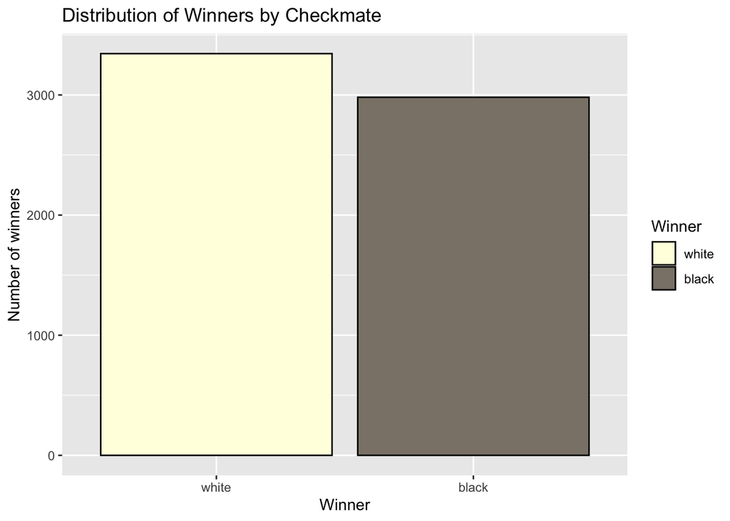

I’m interested in whether player rating could impact the winning results. A boxplot of the winner rating by their chess color shows there is little difference between the player rating of white vs black winners.

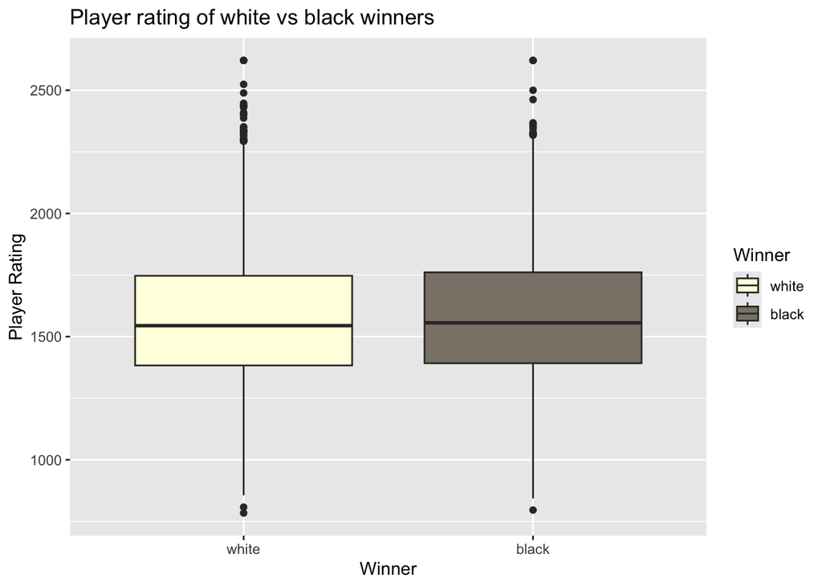

However when taking into account whether the game was a casual game or a rated game, there is a difference between white or black winners.

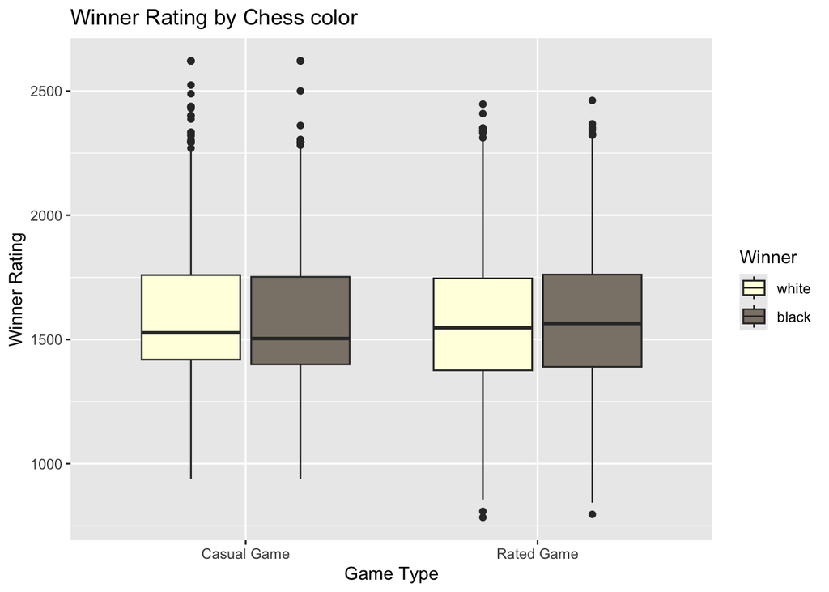

White players have slightly more wins when they’re underleveled compared to their black opponent.

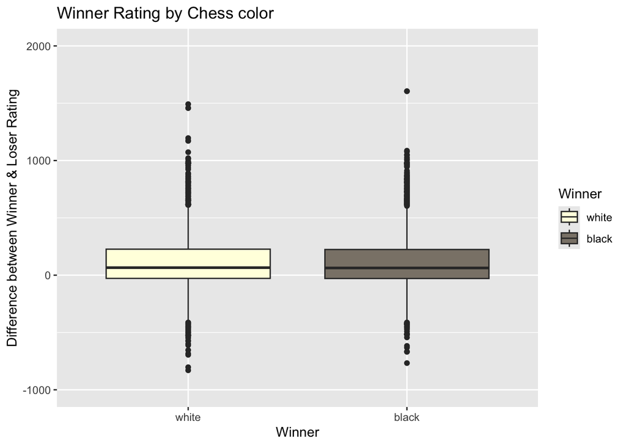

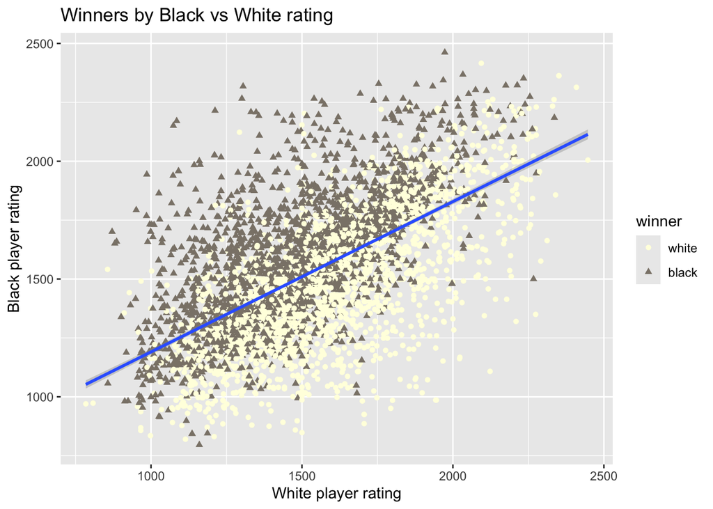

```r
chess_summary2
```

```
## # A tibble: 6,325 × 4
##    winner winner_rating winner_n diff_rating
##    <fct>          <dbl>    <int>       <dbl>
##  1 white           1496        4          -4
##  2 white           1496        4           7
##  3 white           1496        4         180
##  4 white           1496        4         -50
##  5 white           1439        5         -15
##  6 white           1439        5         -15
##  7 white           1439        5         157
##  8 white           1439        5        -106
##  9 white           1439        5         -15
## 10 white           1523        9          54
## # … with 6,315 more rows
```

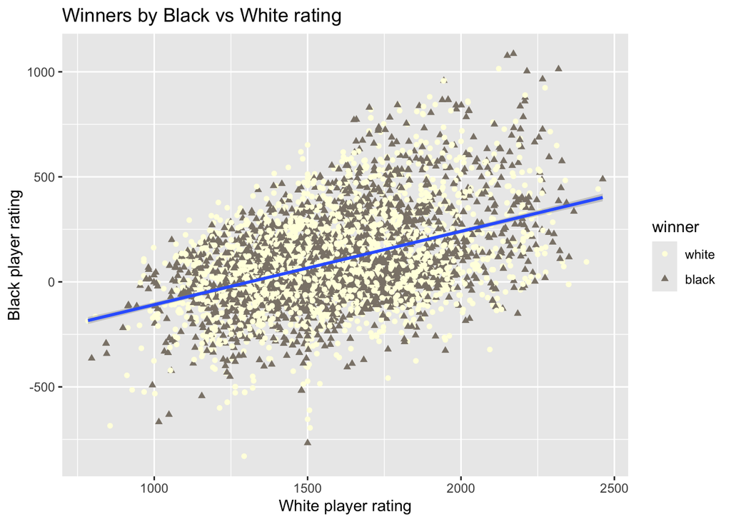

# III. Modeling/analysis:

Now that we see that may be some association between victory and player rating, let’s model the data.

First, I split my data into 80% training and 20% testing data.

```r
# To ensure reproducibility
set.seed(2000)

# Split data into training and test dataset
train_indexes <- as.vector(createDataPartition(chess_clean$winner, p = 0.8, list = FALSE))
chess_train <- slice(chess_clean, train_indexes)
chess_test <- slice(chess_clean, -train_indexes)
```

## Decision trees

We will now fit several classification trees to predict if a game ends in a white winner.

- Decision tree 1: fit a model using the `black player rating` as a predictor variable.
- Decision tree 2: fit a model using the `white player rating` as a predictor variable
- Decision tree 3: fit a model using both `white_rating` and `black_rating`as predictor variables.

### Decision tree 3: both `white_rating` and `black_rating`as predictor variables.

Predicting the winner on the test set using each decision tree, calculating the ROC curve for each decision tree and plot them gives us the following figure:

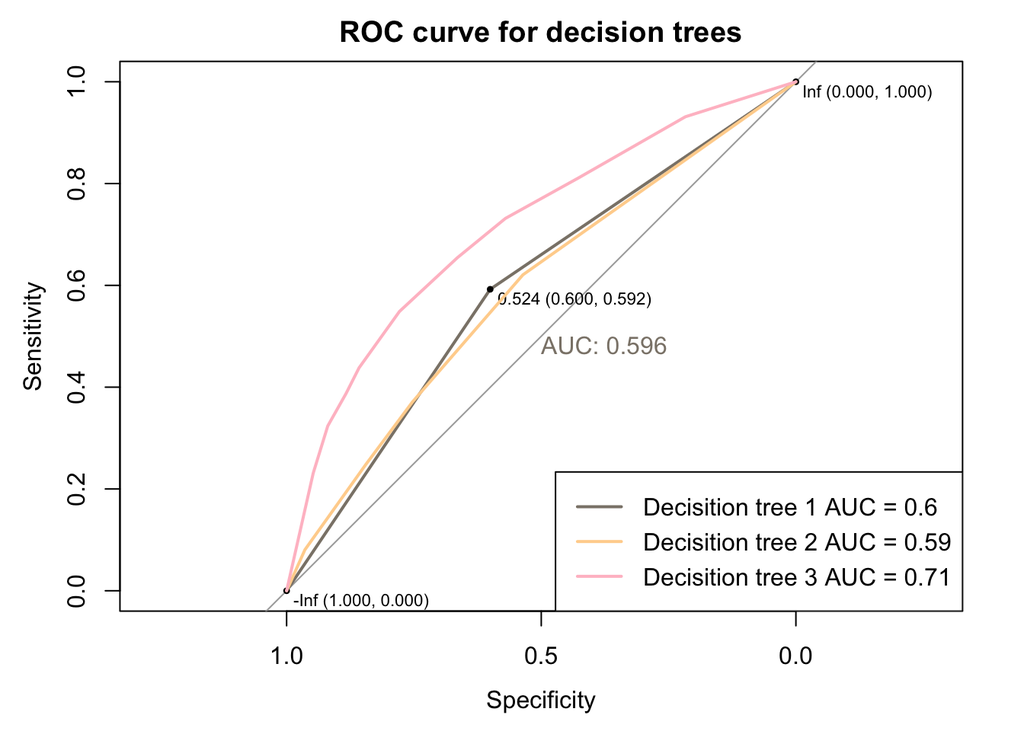

The third decision tree using both `white_rating` and `black_rating`as predictor variables has the highest area under the curve of 0.7132241.

## Random forest model

```r
set.seed(444)
# Select features and fit the model
rf_model <- randomForest(winner ~ ., data = chess_train)

# Inspect the model
rf_model
```

```
##
## Call:
##  randomForest(formula = winner ~ ., data = chess_train)
##                Type of random forest: classification
##                      Number of trees: 500
## No. of variables tried at each split: 2
##
##         OOB estimate of  error rate: 1.8%
## Confusion matrix:
##       white black class.error
## white  2638    38  0.01420030
## black    53  2332  0.02222222
```

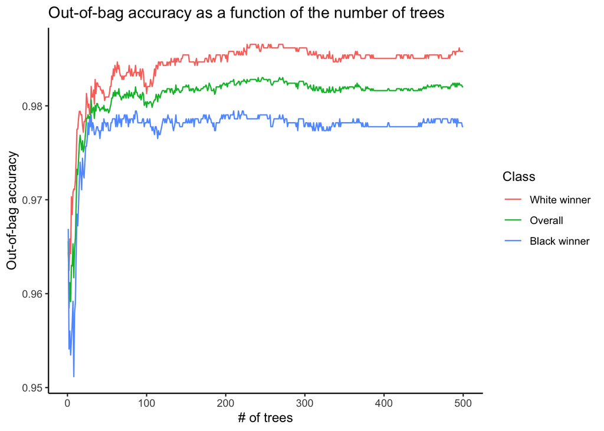

The error rate sort of stabilizes at around 200 trees.

```
## Random Forest
##
## 5061 samples
##    7 predictor
##    2 classes: 'white', 'black'
##
## No pre-processing
## Resampling results across tuning parameters:
##
##   mtry  Accuracy   Kappa
##    1    0.9312389  0.8610842
##    2    0.9830073  0.9658957
##    3    0.9859712  0.9718447
##    4    0.9889350  0.9777905
##    5    0.9917012  0.9833436
##    6    0.9913061  0.9825545
##    7    0.9926892  0.9853282
##    8    0.9917012  0.9833459
##    9    0.9917012  0.9833467
##   10    0.9930844  0.9861200
##
## Accuracy was used to select the optimal model using the largest value.
## The final value used for the model was mtry = 10.
```

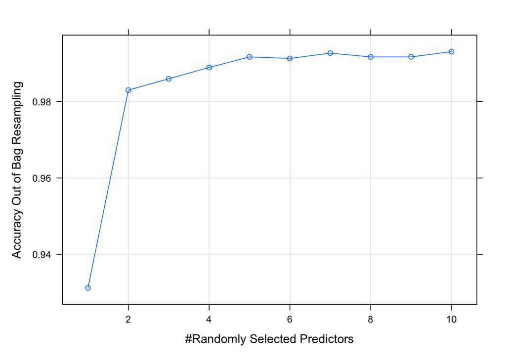

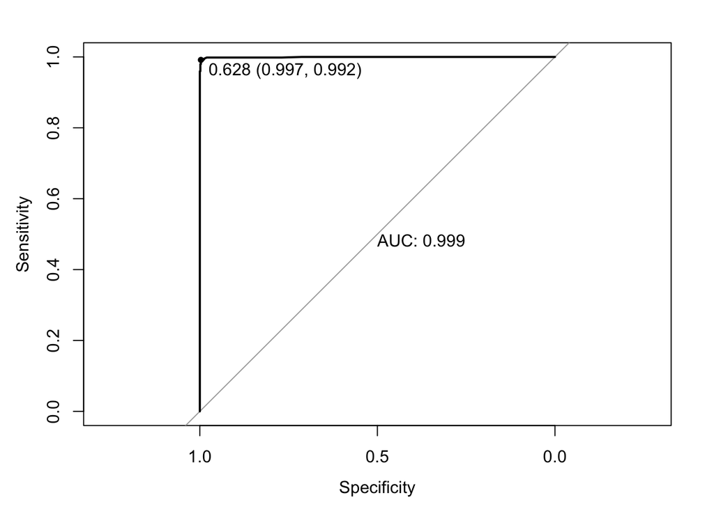

The random forest has a higher accuracy than the decision trees, with an area under the curve of 0.999